# COVID19 EDA for EU

Analyzing data on new daily covid-19 cases and deaths in European Union (EU) and European Economic Area (EEA) countries. Data file may be downloaded [here](https://www.ecdc.europa.eu/en/publications-data/data-daily-new-cases-covid-19-eueea-country)

1. perform an Exploratory Data Analysis (EDA)
2. perform some hypothesis testing
3. perform some correlation testing
4. fit and describe a linear regression model.

A data dictionary for the dataset is available [here](https://www.ecdc.europa.eu/sites/default/files/documents/Description-and-disclaimer_daily_reporting.pdf).

#### 1. Descriptive Statistics

Exploratory Data Analysis (EDA). EDA includes the following:

- Creation of a vector, ‘incidence_rate,’ equal to the daily new cases per 100K individuals, per country. Country populations are provided in ‘popData2020.’ This vector should be added to the ‘data’ data frame.
- Creation of a vector, ‘fatality_rate,’ equal to the new deaths per 100K individuals, per country. Country populations are provided in ‘popData2020.’ This vector should be added to the ‘data’ data frame.
- A visualization exploring new cases or incidence rates, per country, over time. You may choose a subset of countries, if you wish, but your visualization should include at least five (5) countries and include the entire time frame of the dataset.
- A visualization exploring new deaths or fatality rates, per country, over time. You may choose a subset of countries, if you wish, but your visualization should include at least five (5) countries.
- A table or visualization exploring some other aspect of the data. For example, you could explore case fatality rates per country; the number of deaths divided by the total number of cases. Note that to do this, you would want to like across the entire time of the dataset, looking at the total cases and deaths, per country.

```r
# creating vector of incidence_rate

incidence_rate <- round(c((data$cases * 100000)/data$popData2020), digits = 2)

#creating fatality_rate

fatality_rate <- round(c((data$deaths * 100000)/data$popData2020), digits = 4)

#binding incidence_rate and fatality_rate to the data frame

data_new <- data
data_new <- cbind(data, incidence_rate, fatality_rate)
```

```r
#A visualization exploring incidence rates, per country, over time. five (5) countries and include the entire time frame of the dataset.

#5 countries

Country1Sweden <- data_new[data_new$countriesAndTerritories == "Sweden",]
Country2Austria <- data_new[data_new$countriesAndTerritories == "Austria",]
Country3France <- data_new[data_new$countriesAndTerritories == "France",]
Country4Italy <- data_new[data_new$countriesAndTerritories == "Italy",]
Country5Spain <- data_new[data_new$countriesAndTerritories == "Spain",]

Five_Countries <- list(Country1Sweden, Country2Austria, Country3France, Country4Italy, Country5Spain)

Five_Countries_data <- Reduce(function(x, y) merge(x, y, all=TRUE), list(Country1Sweden, Country2Austria, Country3France, Country4Italy, Country5Spain))
```

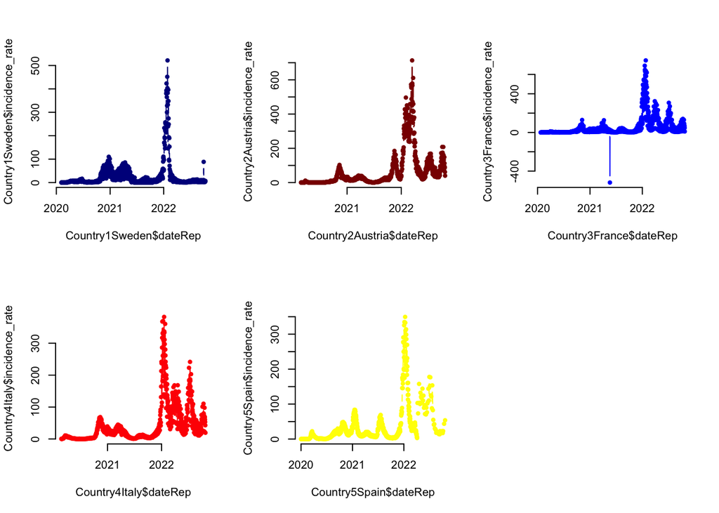

```r
#A visualization exploring new deaths or fatality rates, per country, over time. Visualization should include at least five (5) countries.
#date vs incidence rate by each country side by side

par(mfrow = c(2, 3))

plot(Country1Sweden$dateRep, Country1Sweden$incidence_rate, type = "b", frame = FALSE, pch = 20, col = "darkblue")
plot(Country2Austria$dateRep, Country2Austria$incidence_rate, type = "b", frame = FALSE, pch = 20, col = "darkred")
plot(Country3France$dateRep, Country3France$incidence_rate, type = "b", frame = FALSE, pch = 20, col = "blue")
plot(Country4Italy$dateRep, Country4Italy$incidence_rate, type = "b", frame = FALSE, pch = 20, col = "red")
plot(Country5Spain$dateRep, Country5Spain$incidence_rate, type = "b", frame = FALSE, pch = 20, col = "yellow")

#A visualization exploring new deaths or fatality rates, per country, over time. Visualization should include at least five (5) countries.

#date vs Fatality rate by each country side by side


#group them by country for incidence rate and fatality rate side by side, add ais and plot titles
par(mfrow = c(2, 3))
```

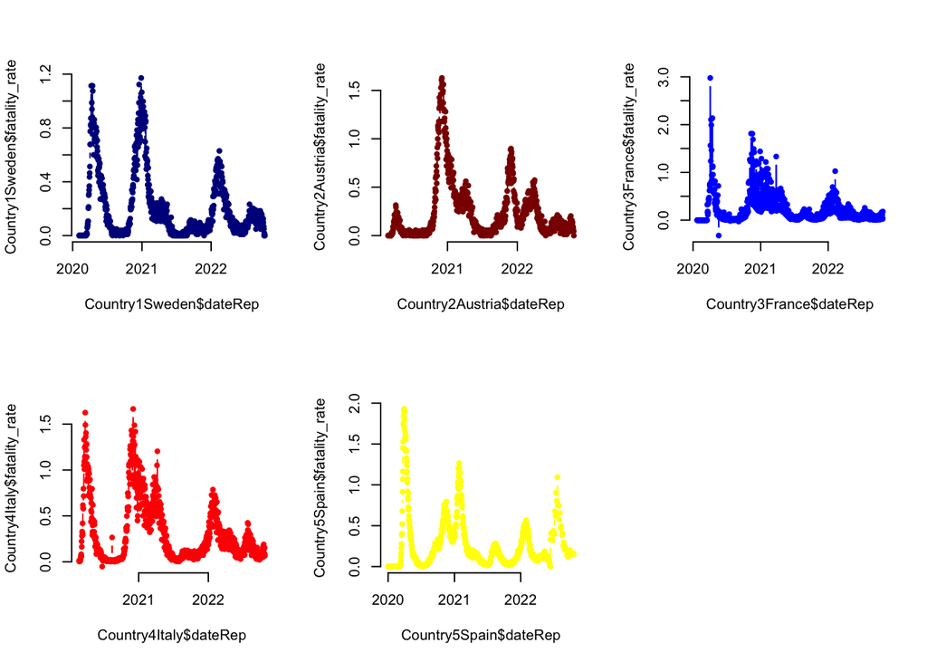

```r
#date by fatality rate
plot(Country1Sweden$dateRep, Country1Sweden$fatality_rate, type = "b", frame = FALSE, pch = 20, col = "darkblue")
plot(Country2Austria$dateRep, Country2Austria$fatality_rate, type = "b", frame = FALSE, pch = 20, col = "darkred")
plot(Country3France$dateRep, Country3France$fatality_rate, type = "b", frame = FALSE, pch = 20, col = "blue")
plot(Country4Italy$dateRep, Country4Italy$fatality_rate, type = "b", frame = FALSE, pch = 20, col = "red")
plot(Country5Spain$dateRep, Country5Spain$fatality_rate, type = "b", frame = FALSE, pch = 20, col = "yellow")

par(mfrow = c(2, 4))
```

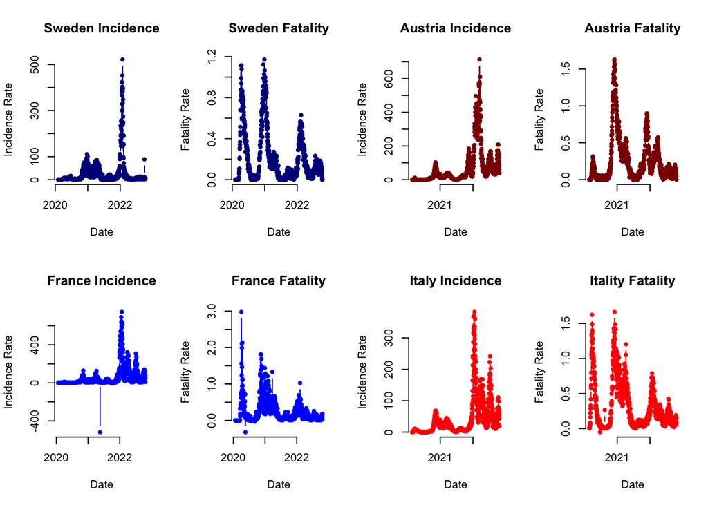

```r
#clean, Organize, lael

#Sweden
plot(Country1Sweden$dateRep, Country1Sweden$incidence_rate, type = "b", frame = FALSE, pch = 20, col = "darkblue", xlab = 'Date', ylab = 'Incidence Rate', main = 'Sweden Incidence')
plot(Country1Sweden$dateRep, Country1Sweden$fatality_rate, type = "b", frame = FALSE, pch = 20, col = "darkblue", xlab = 'Date', ylab = 'Fatality Rate', main = 'Sweden Fatality')

#Austria
plot(Country2Austria$dateRep, Country2Austria$incidence_rate, type = "b", frame = FALSE, pch = 20, col = "darkred", xlab = 'Date', ylab = 'Incidence Rate', main = 'Austria Incidence')
plot(Country2Austria$dateRep, Country2Austria$fatality_rate, type = "b", frame = FALSE, pch = 20, col = "darkred", xlab = 'Date', ylab = 'Fatality Rate', main = 'Austria Fatality')

#France
plot(Country3France$dateRep, Country3France$incidence_rate, type = "b", frame = FALSE, pch = 20, col = "blue", xlab = 'Date', ylab = 'Incidence Rate', main = 'France Incidence')
plot(Country3France$dateRep, Country3France$fatality_rate, type = "b", frame = FALSE, pch = 20, col = "blue", xlab = 'Date', ylab = 'Fatality Rate', main = 'France Fatality')

#Italy
plot(Country4Italy$dateRep, Country4Italy$incidence_rate, type = "b", frame = FALSE, pch = 20, col = "red", xlab = 'Date', ylab = 'Incidence Rate', main = 'Italy Incidence')
plot(Country4Italy$dateRep, Country4Italy$fatality_rate, type = "b", frame = FALSE, pch = 20, col = "red", xlab = 'Date', ylab = 'Fatality Rate', main = 'Itality Fatality')
```

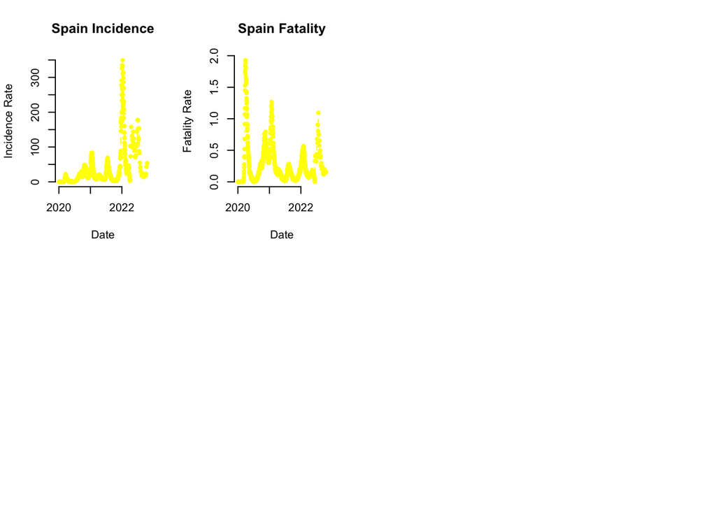

```r
#Spain
plot(Country5Spain$dateRep, Country5Spain$incidence_rate, type = "b", frame = FALSE, pch = 20, col = "yellow", xlab = 'Date', ylab = 'Incidence Rate', main = 'Spain Incidence')
plot(Country5Spain$dateRep, Country5Spain$fatality_rate, type = "b", frame = FALSE, pch = 20, col = "yellow", xlab = 'Date', ylab = 'Fatality Rate', main = 'Spain Fatality')
```

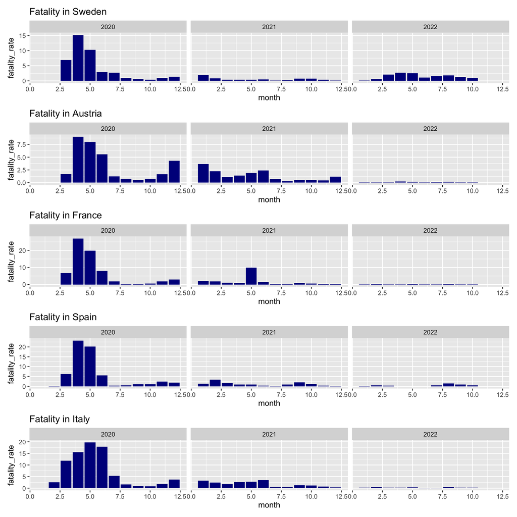

```r
#Sweden Austria France Italy Spain Bar plots of month by fatality rate

p1 <- data_new %>%
  group_by(countriesAndTerritories, month, year) %>%
  summarize(total_cases = sum(cases),
            total_deaths = sum(deaths)) %>%
  mutate(fatality_rate = (total_deaths / total_cases) * 100) %>%
  filter(countriesAndTerritories == "Sweden") %>%
  ggplot(aes(x = month, y = fatality_rate)) +
  geom_bar(stat = "identity", fill = "dark blue") +
  facet_wrap(~year) +
  ggtitle("Fatality in Sweden")

p2 <- data_new %>%
  group_by(countriesAndTerritories, month, year) %>%
  summarize(total_cases = sum(cases),
            total_deaths = sum(deaths)) %>%
  mutate(fatality_rate = (total_deaths / total_cases) * 100) %>%
  filter(countriesAndTerritories == "Austria") %>%
  ggplot(aes(x = month, y = fatality_rate)) +
  geom_bar(stat = "identity", fill = "dark blue") +
  facet_wrap(~year) +
  ggtitle("Fatality in Austria")


p3 <- data_new %>%
  group_by(countriesAndTerritories, month, year) %>%
  summarize(total_cases = sum(cases),
            total_deaths = sum(deaths)) %>%
  mutate(fatality_rate = (total_deaths / total_cases) * 100) %>%
  filter(countriesAndTerritories == "France") %>%
  ggplot(aes(x = month, y = fatality_rate)) +
  geom_bar(stat = "identity", fill = "dark blue") +
  facet_wrap(~year) +
  ggtitle("Fatality in France")


p4 <- data_new %>%
  group_by(countriesAndTerritories, month, year) %>%
  summarize(total_cases = sum(cases),
            total_deaths = sum(deaths)) %>%
  mutate(fatality_rate = (total_deaths / total_cases) * 100) %>%
  filter(countriesAndTerritories == "Spain") %>%
  ggplot(aes(x = month, y = fatality_rate)) +
  geom_bar(stat = "identity", fill = "dark blue") +
  facet_wrap(~year) +
  ggtitle("Fatality in Spain")

p5 <- data_new %>%
  group_by(countriesAndTerritories, month, year) %>%
  summarize(total_cases = sum(cases),
            total_deaths = sum(deaths)) %>%
  mutate(fatality_rate = (total_deaths / total_cases) * 100) %>%
  filter(countriesAndTerritories == "Italy") %>%
  ggplot(aes(x = month, y = fatality_rate)) +
  geom_bar(stat = "identity", fill = "dark blue") +
  facet_wrap(~year) +
  ggtitle("Fatality in Italy")

p1 / p2 / p3 / p4 / p5
```

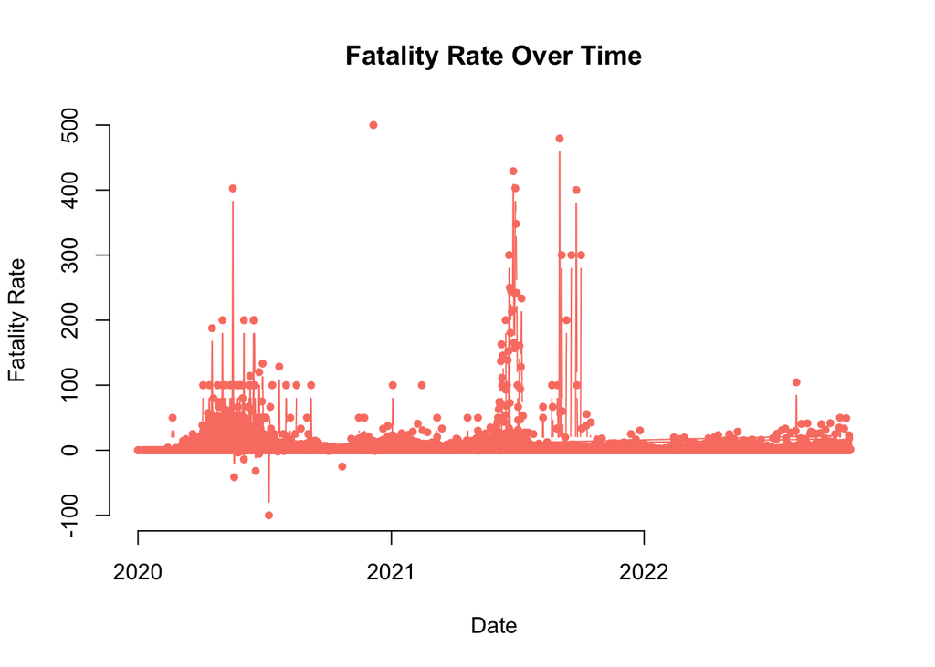

```r
# A Visualization exploring fatality rates per country; the number of deaths divided by the total number of cases.

#fatality rates per country
fatality_rates_per_country <- round(c((data$deaths/data$cases)*100), digits = 4)

data_new <- cbind(data_new, fatality_rates_per_country)

#plot fatality rates over time for all countries

plot(data_new$dateRep, data_new$fatality_rates_per_country, type = "b", frame = FALSE, pch = 20, col = "salmon", xlab = 'Date', ylab = 'Fatality Rate', main = 'Fatality Rate Over Time')
```

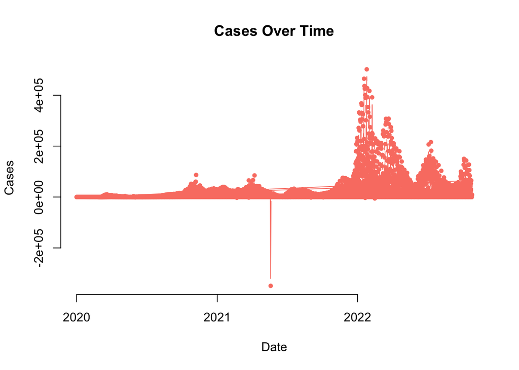

```r
#plot cases over time

plot(data_new$dateRep, data_new$cases, type = "b", frame = FALSE, pch = 20, col = "salmon", xlab = 'Date', ylab = 'Cases', main = 'Cases Over Time')
```

```r
#Correlation cases and deaths:

#correlation check of cases vs deaths
corr_cases_death <- cor.test(data_new$cases, data_new$deaths, method = "kendall")
corr_cases_death
```

```
##
##  Kendall's rank correlation tau
##
## data:  data_new$cases and data_new$deaths
## z = 142.92, p-value < 2.2e-16
## alternative hypothesis: true tau is not equal to 0
## sample estimates:
##       tau
## 0.5877236
```

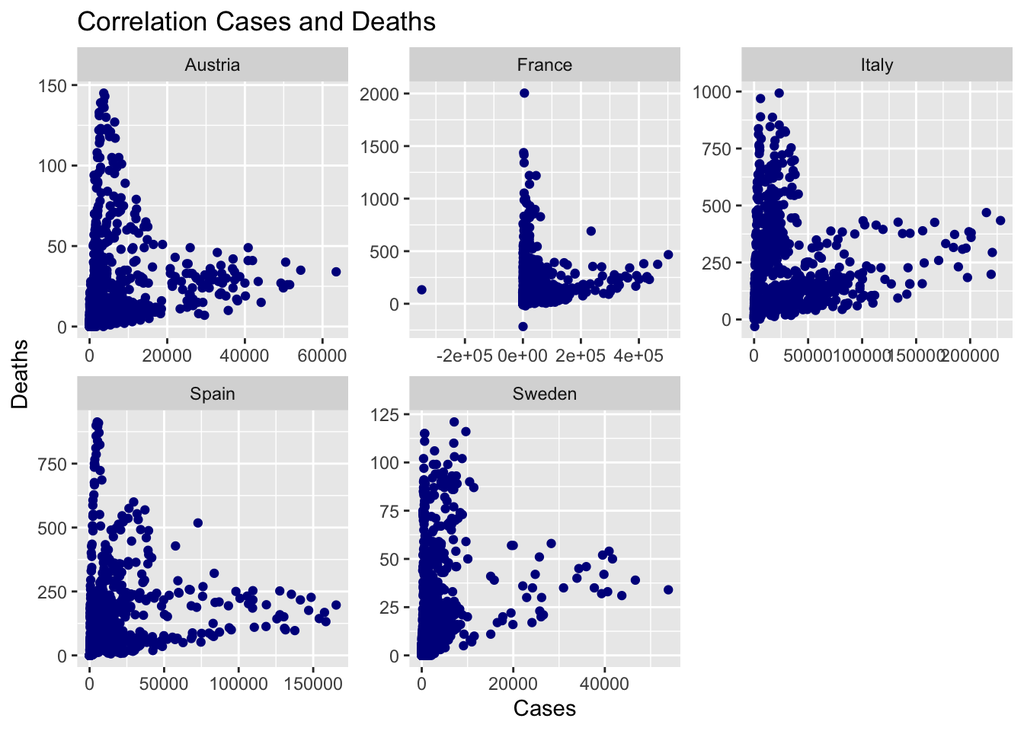

```r
data_new %>%
  filter(countriesAndTerritories %in% c("Sweden", "Austria", "France", "Italy", "Spain")) %>%
  ggplot(aes(x = cases, y = deaths)) +
  geom_point(color = "dark blue") +
  facet_wrap(~ countriesAndTerritories, scales = "free") +
  labs(x = "Cases", y = "Deaths", title = "Correlation Cases and Deaths")
```

```r
#correlation check of Incidence Rate vs fatality rate and fatality rate per country
corr_Incidence_Fatality <- cor.test(data_new$incidence_rate, data_new$fatality_rate, method = "kendall")
corr_Incidence_Fatality
```

```
##
##  Kendall's rank correlation tau
##
## data:  data_new$incidence_rate and data_new$fatality_rate
## z = 102.92, p-value < 2.2e-16
## alternative hypothesis: true tau is not equal to 0
## sample estimates:
##       tau
## 0.4199618
```

```r
corr_Incidence_Fatality_per_country <- cor.test(data_new$incidence_rate, data_new$fatality_rates_per_country, method = "kendall")
corr_Incidence_Fatality_per_country
```

```
##
##  Kendall's rank correlation tau
##
## data:  data_new$incidence_rate and data_new$fatality_rates_per_country
## z = -20.192, p-value < 2.2e-16
## alternative hypothesis: true tau is not equal to 0
## sample estimates:
##        tau
## -0.0835735
```

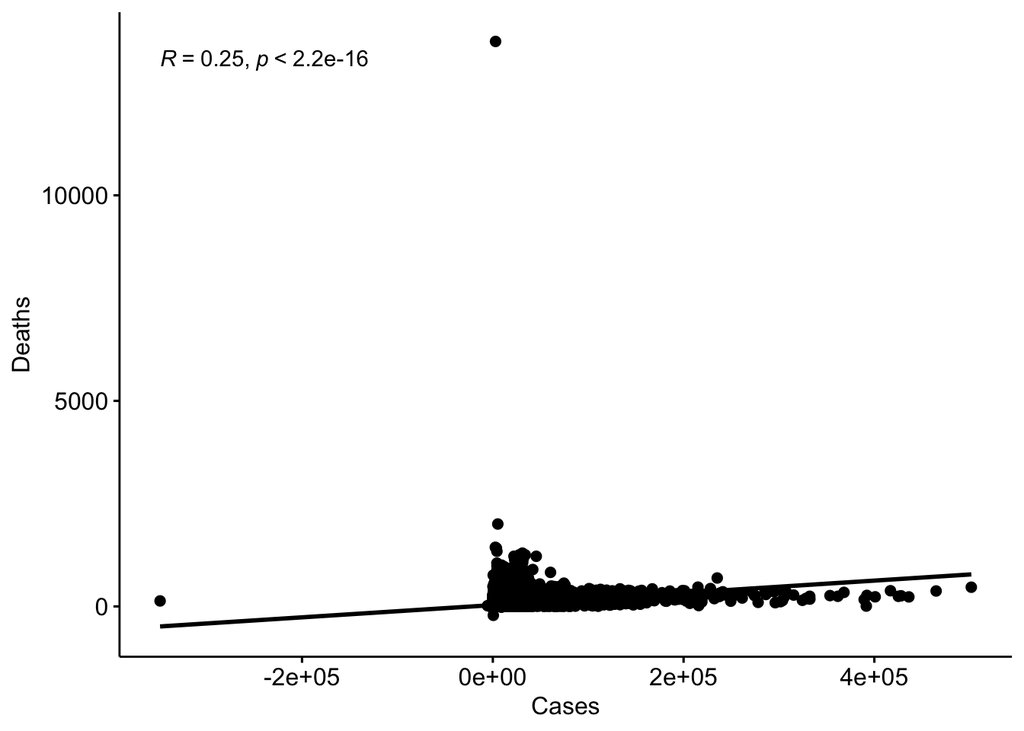

```r
# Correlation of Deaths and Cases, Incidence Rate and Fatality Rate, Incidence Rate and Fatality Rate per Country
par(mfrow = c(3, 1))
library("ggpubr")
ggscatter(data_new, x = "cases", y = "deaths",
          add = "reg.line", conf.int = TRUE,
          cor.coef = TRUE, cor.method = "pearson",
          xlab = "Cases", ylab = "Deaths")
```

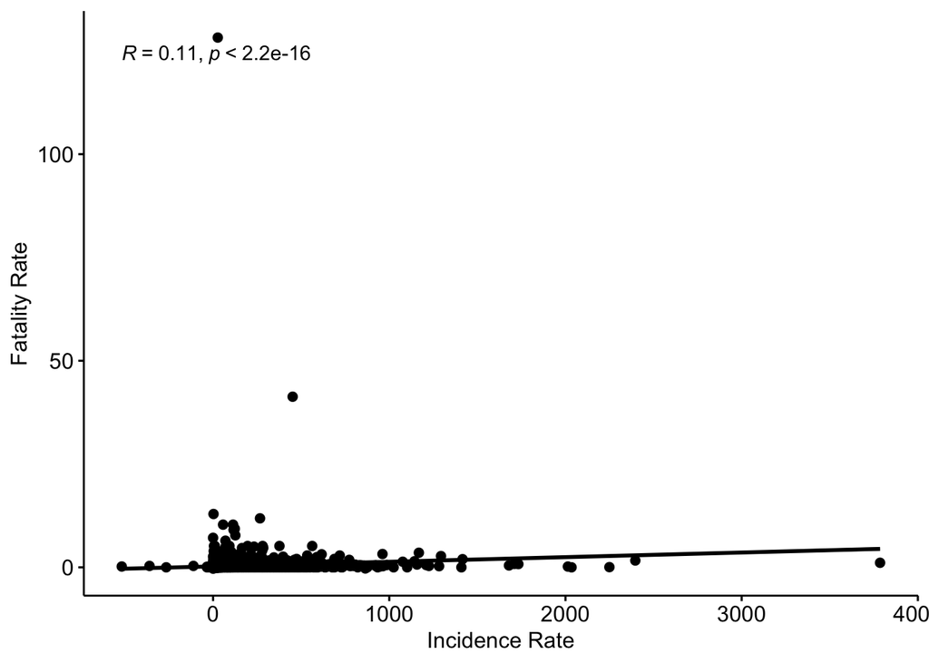

```r
ggscatter(data_new, x = "incidence_rate", y = "fatality_rate",
          add = "reg.line", conf.int = TRUE,
          cor.coef = TRUE, cor.method = "pearson",
          xlab = "Incidence Rate", ylab = "Fatality Rate")
```

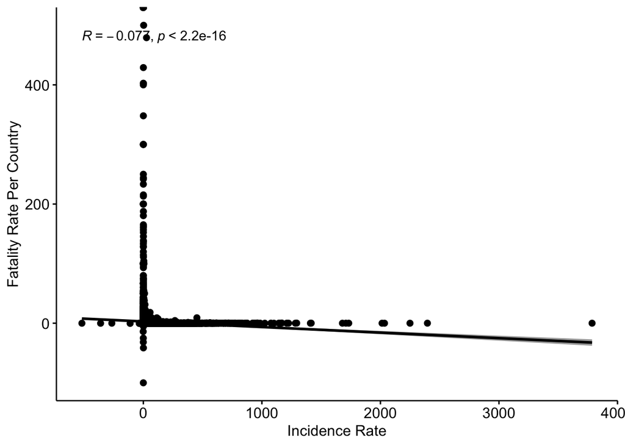

```r
ggscatter(data_new, x = "incidence_rate", y = "fatality_rates_per_country",
          add = "reg.line", conf.int = TRUE,
          cor.coef = TRUE, cor.method = "pearson",
          xlab = "Incidence Rate", ylab = "Fatality Rate Per Country")
```

```r
# Table groupedby country

data_new %>%
  group_by(countriesAndTerritories) %>%
  summarize(total_cases = sum(cases, na.rm = TRUE), total_deaths = sum(deaths, na.rm = TRUE)) %>%
  mutate(fatality_rate = (total_deaths / total_cases) * 100)
```

```
## # A tibble: 30 × 4
##    countriesAndTerritories total_cases total_deaths fatality_rate
##    <fct>                         <int>        <int>         <dbl>
##  1 Austria                     5402162        20899         0.387
##  2 Belgium                     4607296        32883         0.714
##  3 Bulgaria                    1275481        37790         2.96
##  4 Croatia                     1244692        17085         1.37
##  5 Cyprus                       596297         1191         0.200
##  6 Czechia                     4152997        41524         1.00
##  7 Denmark                     3219571         7274         0.226
##  8 Estonia                      606268         2739         0.452
##  9 Finland                     1335318         6407         0.480
## 10 France                     36612627       156509         0.427
## # … with 20 more rows
```